# DS5220 Project 1

Naman Singhal

Feb 8 2024

## Instructions

R has excellent visualization capabilities, especially with the `ggplot2` package. Please read Chapter 3 of [*R for Data Science [GW],* Garrett Grolemund, Hadley Wickham](https://r4ds.had.co.nz), and complete the exercises below after you finish each section. Edit the markdown file which came with this html directly. Make sure to enter your R code in the chunks following each question to demonstrate your answers. Follow each code block with a text description of your solution. Answers without demonstration will be given little credit. Code with no description (if requested) will be given little credit.

## 3.2.4 Exercises

##### 1. Run ggplot(data = mpg). What do you see?

```r
ggplot(data = mpg)
```

[output not shown]

```r
ggplot(mpg) + geom_point(mapping = aes(y = hwy, x = cyl))
```

[output not shown]

##### 2. How many rows are in mpg? How many columns? Demonstrate how you obtained your answers using R.

```r
nrow(mpg)
```

```
## [1] 234
```

```r
ncol(mpg)
```

```
## [1] 11
```

We have 234 rows and 11 columns in the mpg dataset. nrow() function gives us the number of Rows and ncol() gives us number of columns

##### 3. What does the `drv` variable describe? Read the Help Panel in RStudio by typing `?mpg` in the Console Panel to find out. (You will see no output from RMarkdown here.) Produce a description of `drv` by typing `mpg` below.

```r
?mpg
print("drv:f = front-wheel drive, r = rear wheel drive, 4 = 4wd")
```

```
## [1] "drv:f = front-wheel drive, r = rear wheel drive, 4 = 4wd"
```

It describes the type of drive on the vehicle. Field is populated with wither **f** for front wheel drive, **r** for rear and **4** for all 4 wheel drive.

##### 4. Make a scatterplot of `hwy` vs `cyl` using `geom_point`.

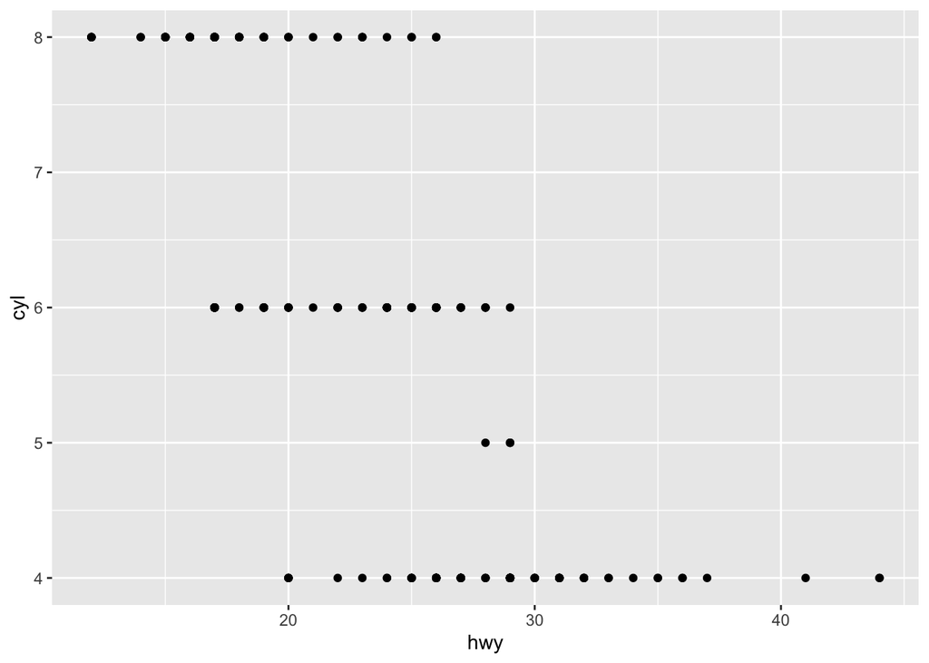

```r
ggplot(data = mpg) +
  geom_point(mapping = aes(x = hwy, y = cyl))
```

In the above geom_point adds a layer for scatter plot on ggplot. AES is used to map coorinates.

##### 5. What happens if you make a scatterplot of `class` vs `drv`? Why is the plot not useful?

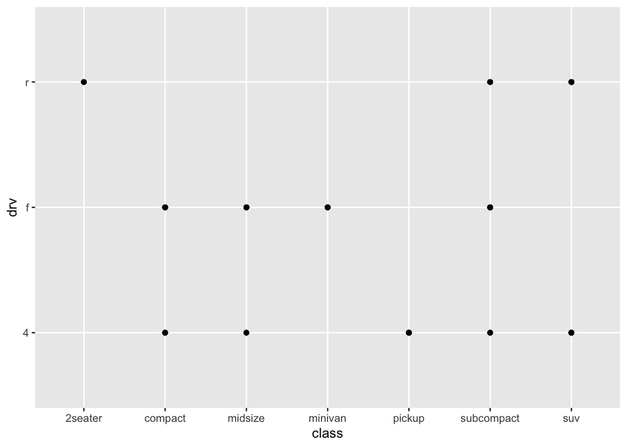

```r
ggplot(data = mpg) +
  geom_point(mapping = aes(x = class, y = drv))
```

From the data points there is no pattern in data, meaning that **class** is weakly correlated with **drv**.